# Task_13

watsoncl

## Reading

This reading will help you complete the tasks below.

o [Chapter 15: R for Data Science - Factors](http://r4ds.had.co.nz/factors.html)

o [Statistical Concepts in Presenting Data (pgs 72 - 85)](http://biostat.mc.vanderbilt.edu/wiki/pub/Main/RafeDonahue/fscipdpfcbg_currentversion.pdf)

o [forcats R package](http://stat545.com/block029_factors.html)

## Tasks

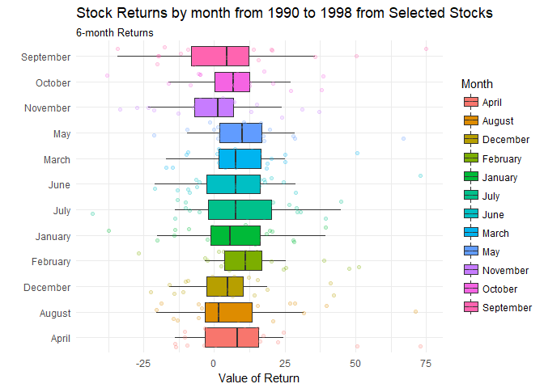

```r
ggplot(data = Stock, mapping = aes(x = month_end, y = value)) +
  geom_boxplot(mapping = aes(group = month_end, fill = month_end),
               outlier.shape = NA) +
  geom_jitter(mapping = aes(color = month_end), alpha = 0.2) +
  theme_minimal() +
  labs(x = "",
       y = "Value of Return",
       title = "Stock Returns by month from 1990 to 1998 from Selected Stocks",
       subtitle = "6-month Returns",
       fill = "Month",
       color = "Month") +
  coord_flip()
```

This graphic allows us to see the returns through the years of the given data set, by grouping them in the respective months. The boxplot across the graphic allows us to see the percentiles and where the jittered data points fall, in reference to the rest, while allowing us to see trends. This allows for us to see the trend that happens along the months, given eight years of data. It appears that they all seem to be fairly similar across the months. If I were to pick a month based on this data to get my six month return, I would pick July as that month has a higher 75th percentile.